# Base Plotting Demonstation

Mr. Sachin B.

24/03/2021

### 1. Histogram

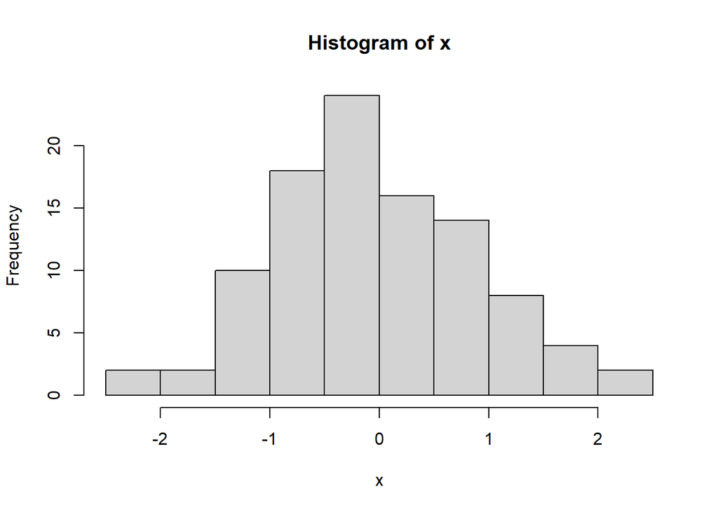

```r
# 100 random numbers using  normal distribution
x<-rnorm(100)

# Histogram
hist(x)
```

### 2. Scatter Plot

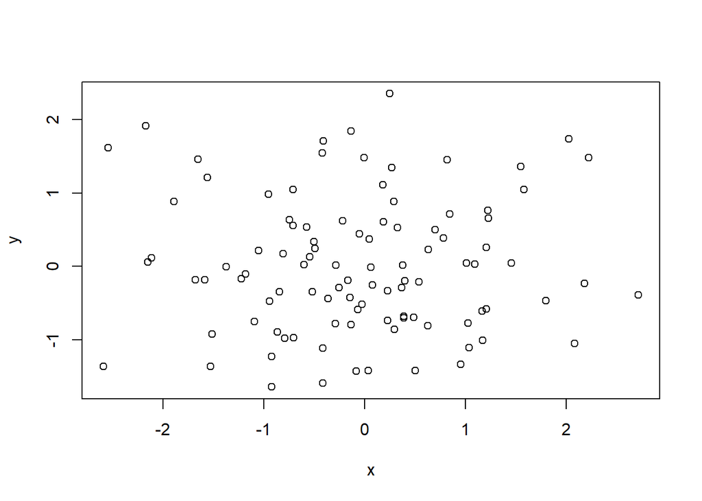

```r
# 100 random numbers using  normal distribution
x <- rnorm(100)
y <- rnorm(100)

# Scatter Plot
plot(x,y)
```

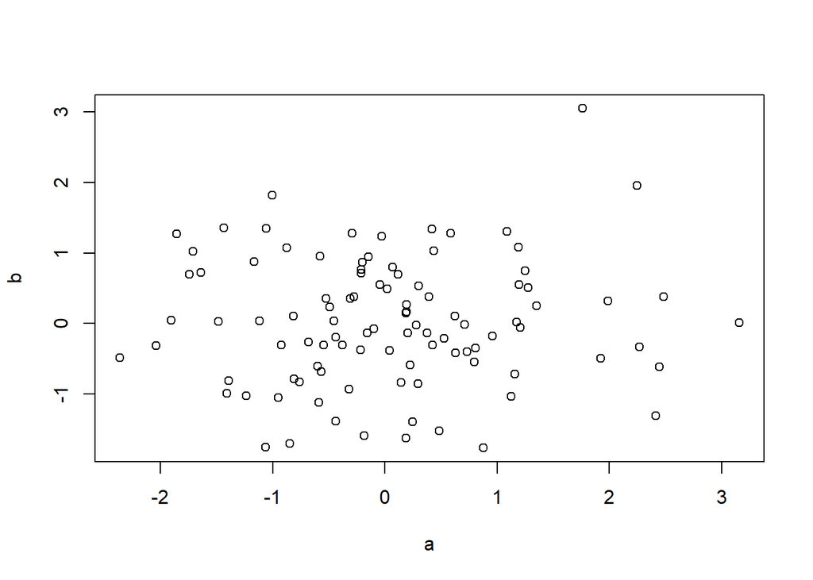

```r
# Scatter Plot Practice
a <- rnorm(100)
b <- rnorm(100)
plot(a,b)
```

### 3. Plot Parameter

#### 3.1 `Margin`

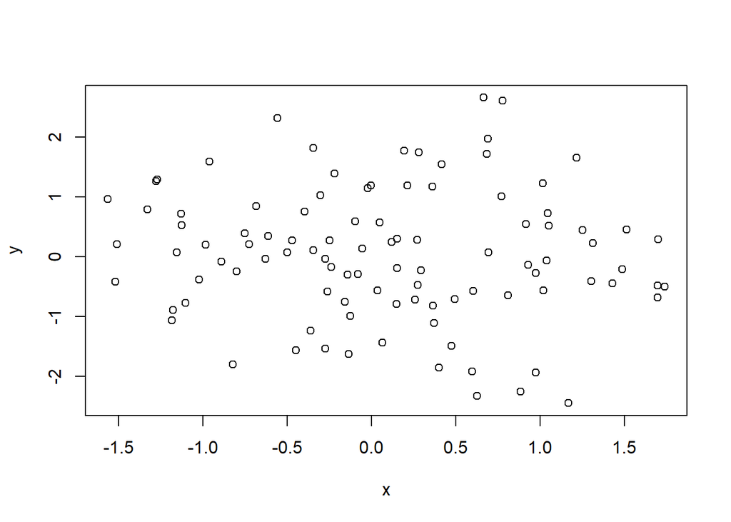

```r
# 100 random numbers using  normal distribution
x <- rnorm(100)
y <- rnorm(100)

# Scatter Plot Before Applying Margin (Default Margin)
plot(x,y)
```

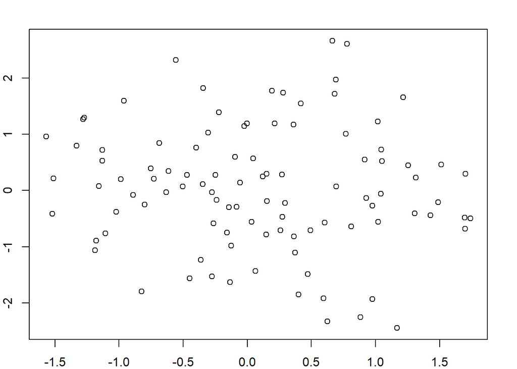

```r
# Adding Margin to Scatter Plot
par(mar = c(2,2,2,2))

# Scatter Plot After Applying Margin
plot(x,y)
```

#### 3.2 `pch`

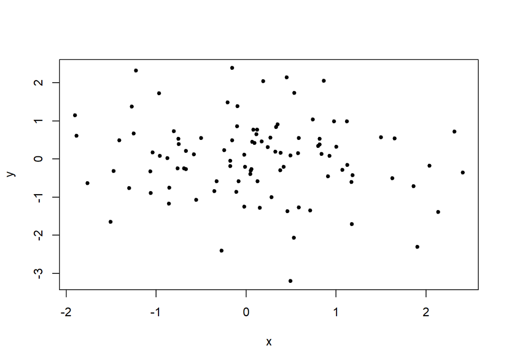

```r
# 100 random numbers using  normal distribution
x <- rnorm(100)
y <- rnorm(100)


# Scatter Plot using pch=20
plot(x,y,pch=20)
```

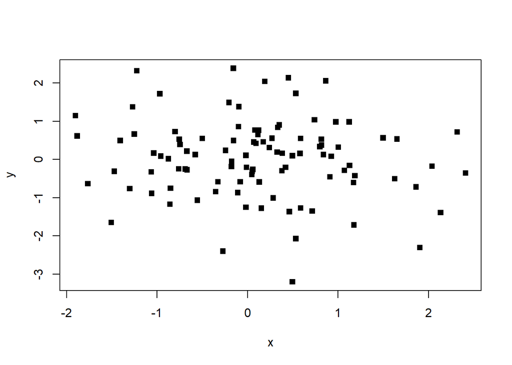

```r
# Scatter Plot using pch=15
plot(x,y,pch=15)
```

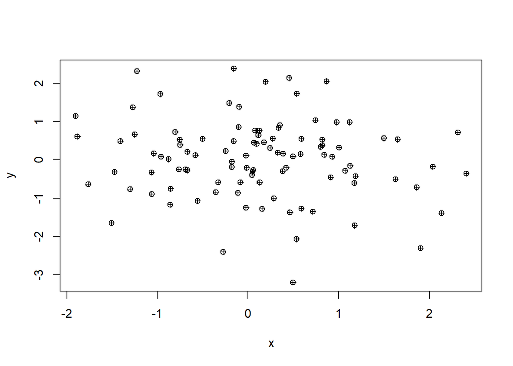

```r
# Scatter Plot using pch=10
plot(x,y,pch=10)
```

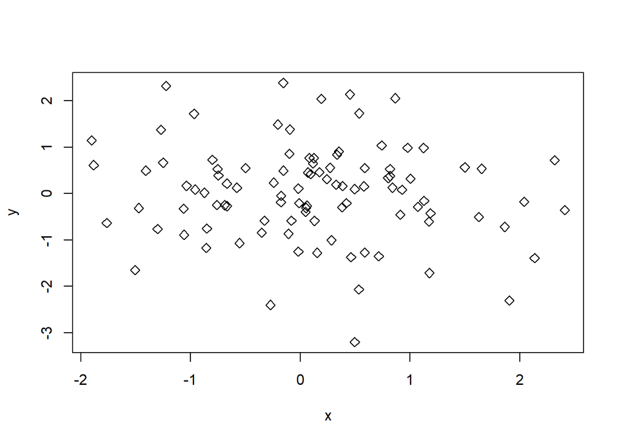

```r
# Scatter Plot using pch=5
plot(x,y,pch=5)
```

#### To know more about pch symbol

```r
example("points")
```

#### 3.3 `title`

##### Approach 1

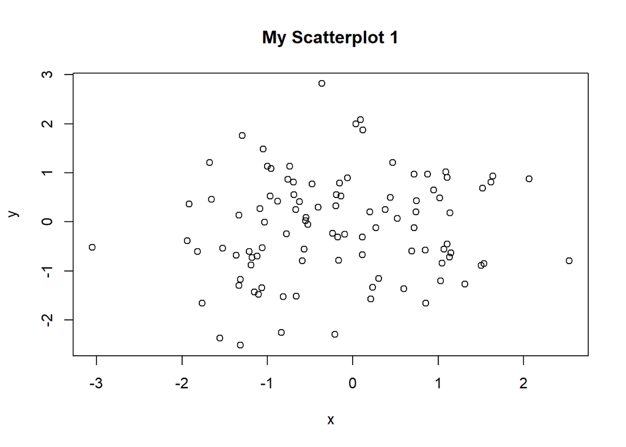

```r
# 100 random numbers using  normal distribution
x <- rnorm(100)
y <- rnorm(100)

# Scatter Plot
plot(x,y)

# Adding Title to Plot
title("My Scatterplot 1")
```

##### Approach 2

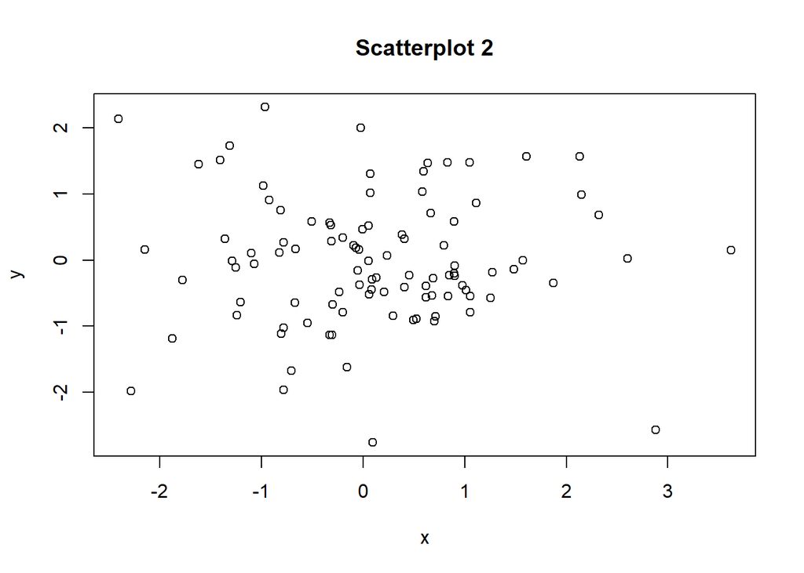

```r
# 100 random numbers using  normal distribution
x <- rnorm(100)
y <- rnorm(100)

# Scatter Plot along with title
plot(x,y, main="Scatterplot 2")
```

#### 3.4 `text`

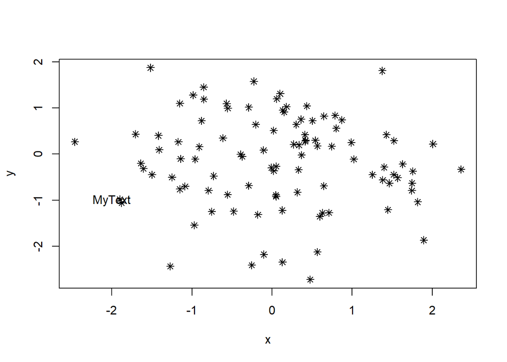

```r
# 100 random numbers using  normal distribution
x <- rnorm(100)
y <- rnorm(100)

# Scatter Plot
plot(x,y,pch=8)

# Adding Text in a Plot
text(-2,-1,"MyText")
```

#### 3.5 `legend`

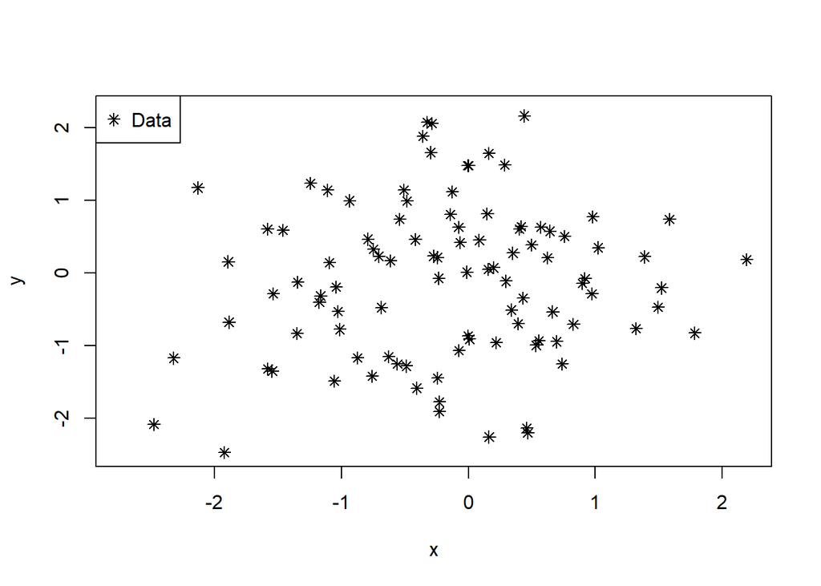

```r
# 100 random numbers using  normal distribution
x <- rnorm(100)
y <- rnorm(100)

# Scatter Plot
plot(x,y,pch=8)

# Adding Legend to a Plot
legend("topleft",legend = "Data", pch = 8)
```

#### 3.6 `abline`

`abline` function adds one or more straight lines through the current plot.

The basic syntax is of abline() is as follows:

`abline(a=NULL, b=NULL, h=NULL, v=NULL, …)`

- a, b: single values that specify the intercept`(a)` and slope`(b)` of the line
- h: the y-value for the horizontal line
- v: the x-value for the vertical line

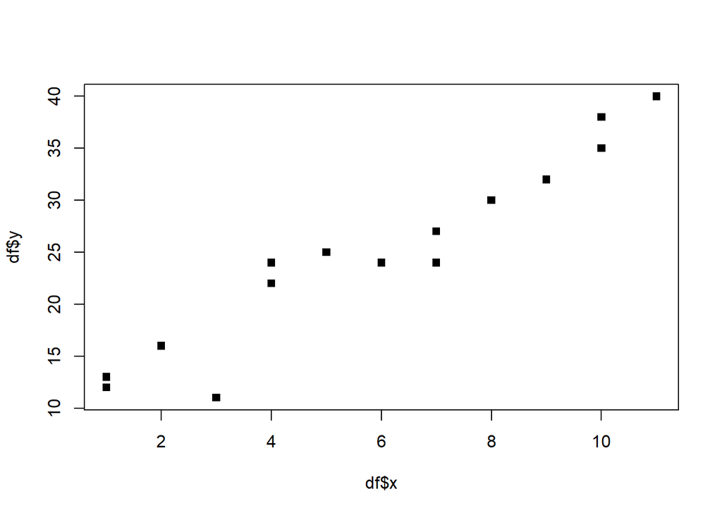

```r
#define dataset

df <- data.frame(x = c(1,1,2,3,4,4,5,6,7,7,8,9,10,10,11),
                 y = c(12,13,16,11,22,24,25,24,24,27,30,32,35,38,40))

#plot x and y values in dataset
plot(df$x, df$y, pch = 15)
```

##### 3.6.1 `abline`:`Horizontal Line`

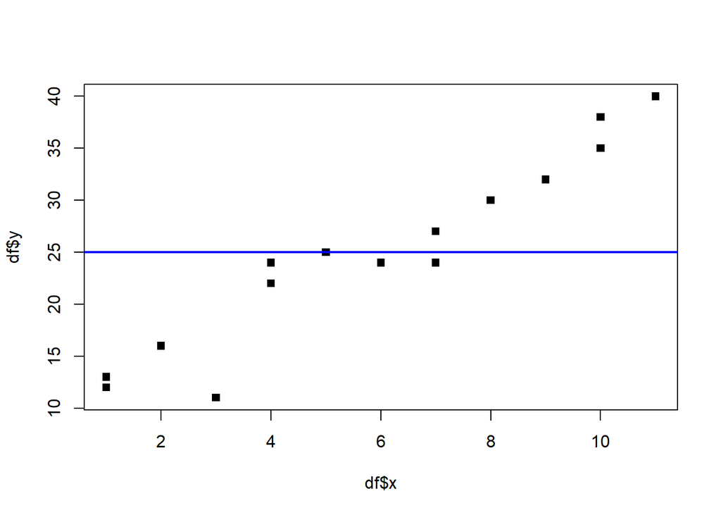

```r
# To add a horizontal line at the value y = 25
plot(df$x, df$y, pch = 15)

abline(h = 25, col = 'blue', lwd = 2)
```

The following code illustrates how to add a horizontal solid line at the mean value of y along with two horizontal dashed lines at one standard deviation above and below the mean value

- Note that lwd = 2 specifies that we want the line width to be equal to 2 (default = 1).
- Note that lty = 2 specifies that we want the line to be dashed.

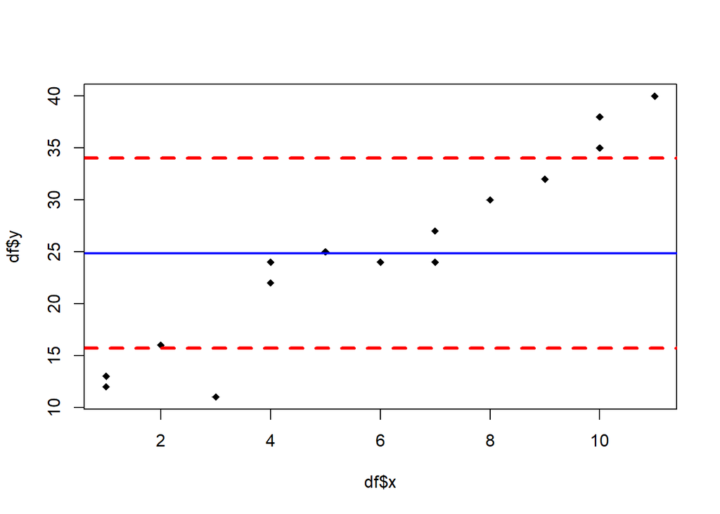

```r
#create scatterplot for x and y
plot(df$x, df$y, pch = 18)

#create horizontal line at mean value of y
abline(h = mean(df$y), col='blue', lwd = 2)

#create horizontal lines at one standard deviation above and below the mean value
abline(h = mean(df$y) + sd(df$y), col = 'red', lwd = 3, lty = 2)
abline(h = mean(df$y) - sd(df$y), col = 'red', lwd = 3, lty = 2)
```

##### 3.6.2 `abline`:`Vertical Line`

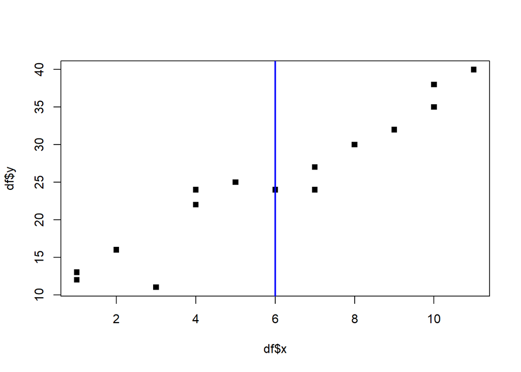

```r
# To add a vertical line at the value x = 6
plot(df$x, df$y, pch = 15)

abline(v = 6, col = 'blue', lwd = 2)
```

The following code illustrates how to add a vertical line at the mean value on a histogram

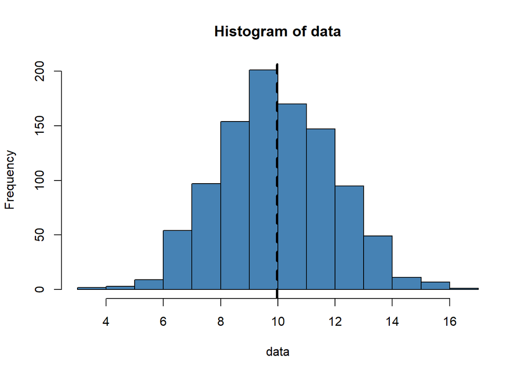

```r
#make this example reproducible
set.seed(0)

#create dataset with 1000 random values normally distributed with mean = 10, sd = 2
data <- rnorm(1000, mean = 10, sd = 2)

#create histogram of data values
hist(data, col = 'steelblue')

#draw a vertical dashed line at the mean value
abline(v = mean(data), lwd = 3, lty = 2)
```

##### 3.6.3 `abline`:`Regression Line`

The basic code to add a simple linear regression line to a plot in R is: `abline(reg_model)`

- where `reg_model` is a fitted regression line created by using the `lm()` function.

The following code illustrates how to add a fitted linear regression line to a scatterplot

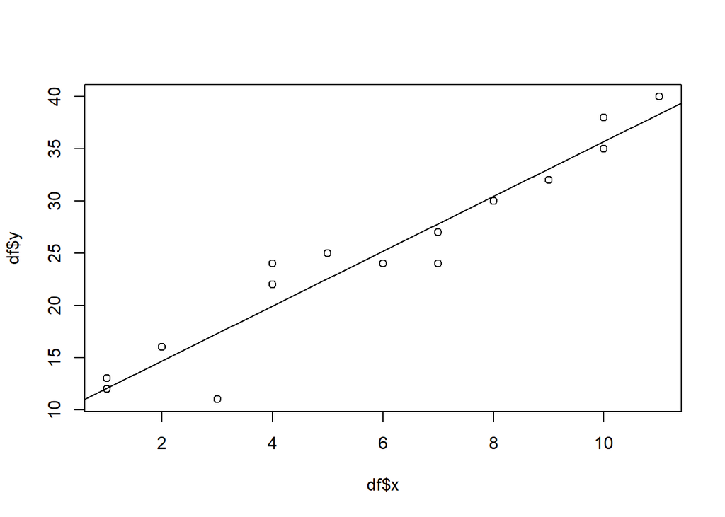

```r
#create scatterplot of x and y values
plot(df$x, df$y)

#fit a linear regression model to the data
reg_model <- lm(y ~ x, data = df)

#add the fitted regression line to the scatterplot
abline(reg_model)
```

Note that we simply need a value for the intercept and the slope to fit a simple linear regression line to the data using the abline() function.

Thus, another way (although a more tedious way) of using abline() to add a regression line is to explicitly specify the intercept and slope coefficients of the regression model:

```r
#define dataset
df <- data.frame(x = c(1,1,2,3,4,4,5,6,7,7,8,9,10,10,11),
                 y = c(12,13,16,11,22,24,25,24,24,27,30,32,35,38,40))

#plot x and y values in dataset
plot(df$x, df$y, xlim = c(0,10), ylim = c(0,40))

#fit a linear regression model to the data
reg_model <- lm(y ~ x, data = df)
print(reg_model)
```

```
##
## Call:
## lm(formula = y ~ x, data = df)
##
## Coefficients:
## (Intercept)            x
##       9.432        2.631
```

```r
print(class(reg_model))
```

```
## [1] "lm"
```

```r
print(typeof(reg_model))
```

```
## [1] "list"
```

```r
#define intercept and slope values
a <- coefficients(reg_model)[1] #intercept
b <- coefficients(reg_model)[2] #slope

print(a)
```

```
## (Intercept)
##    9.431507
```

```r
print(b)
```

```
##        x
## 2.630993
```

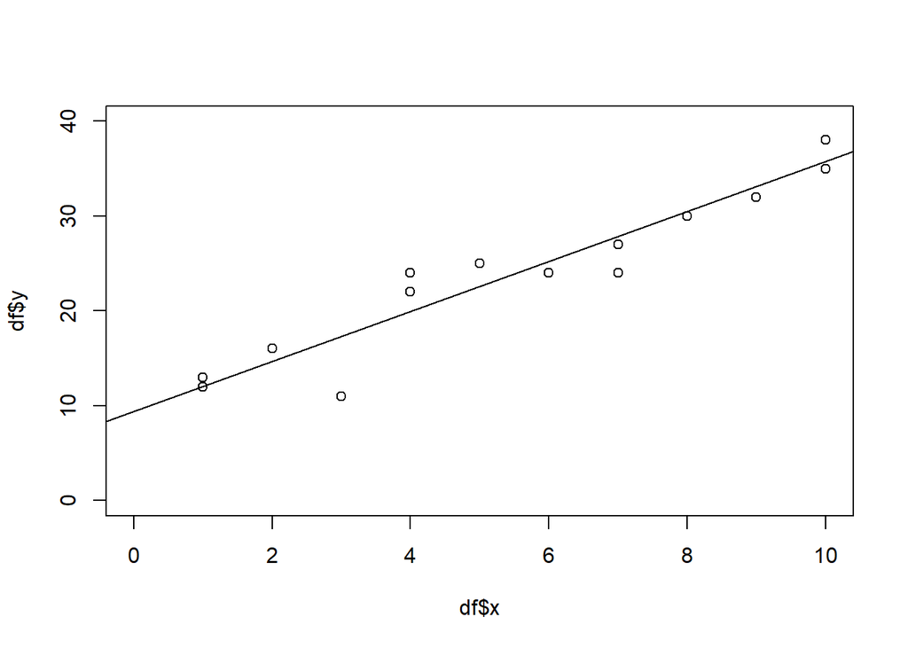

```r
#add the fitted regression line to the scatterplot
abline(a=a, b=b)
```

### Slope and intercept of the regression line

- Slope indicates the steepness of a line
- Intercept indicates the location where it intersects an axis
- The slope and the intercept define the linear relationship between two variables, and can be used to estimate an average rate of change.
- The greater the magnitude of the slope, the steeper the line and the greater the rate of change.

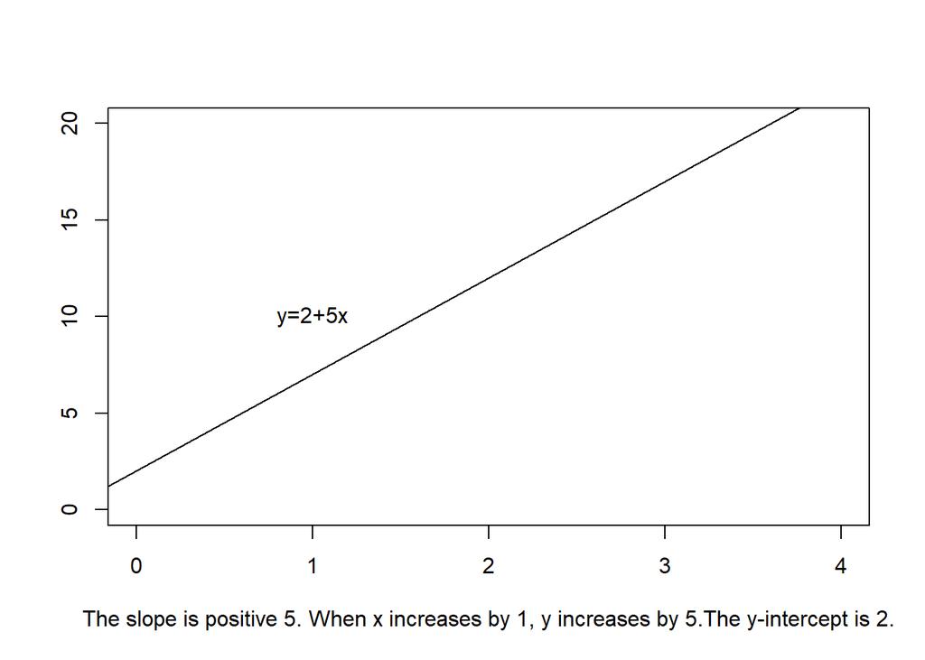

```r
# y=2+5x
plot(1,type = "n", xlab = "The slope is positive 5. When x increases by 1, y increases by 5.The y-intercept is 2.",ylab = "",  xlim = c(0,4), ylim = c(0,20))

text(1,10,"y=2+5x")
abline(a=2, b=5)
```

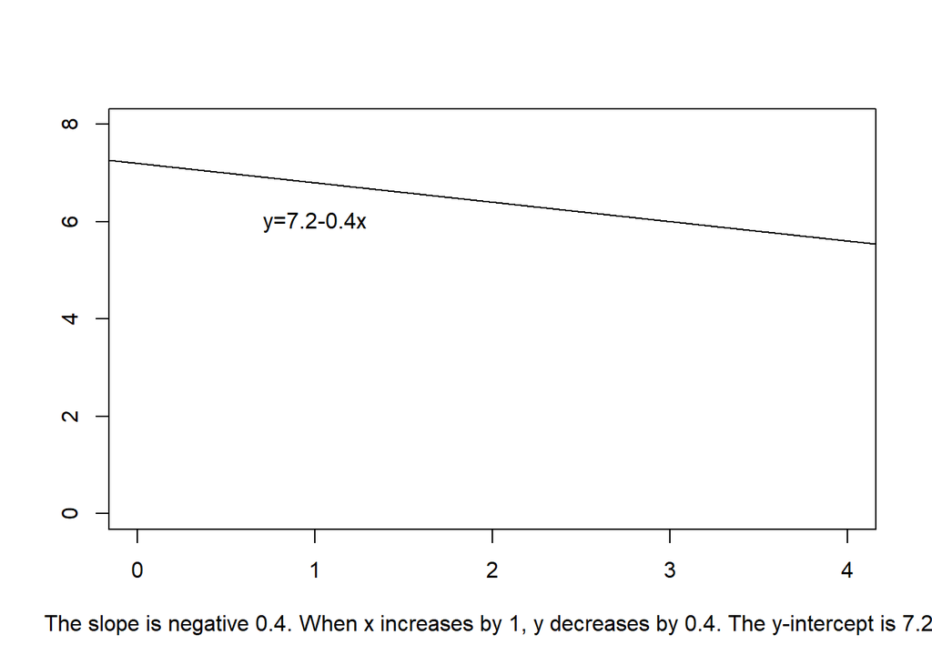

```r
# y=7.2-0.4x
plot(1,type = "n", xlab = "The slope is negative 0.4. When x increases by 1, y decreases by 0.4. The y-intercept is 7.2.",ylab = "",  xlim = c(0,4), ylim = c(0,8))

text(1,6,"y=7.2-0.4x")
abline(a=7.2, b=-0.4)
```

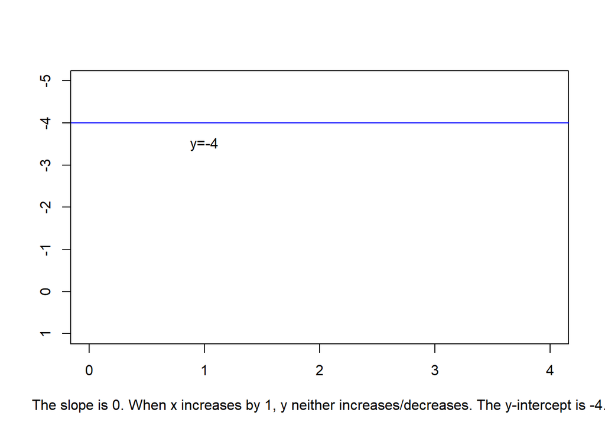

```r
# y=-4
plot(1,type = "n", xlab = "The slope is 0. When x increases by 1, y neither increases/decreases. The y-intercept is -4.",ylab = "",  xlim = c(0,4), ylim = c(1,-5))

text(1,-3.5,"y=-4")
abline(a=-4, b=0, col="blue")
```

Usually, this relationship can be represented by the equation $y = b_0 + b_1x$, where $b_0$ is the $y-intercept$ and $b_1$ is the $slope$.

#### Example

A company determines that job performance for employees in a production department can be predicted using the regression model $y = 130 + 4.3x$  
where,

- $x$ is the hours of in-house training they receive (from 0 to 20)
- $y$ is their score on a job skills test.
- The value of the $y-intercept$ ($130$) indicates the average job skill score for an employee with no training.
- The value of the $slope$ ($4.3$) indicates that for each hour of training, the job skill score increases, on average, by $4.3$ points.

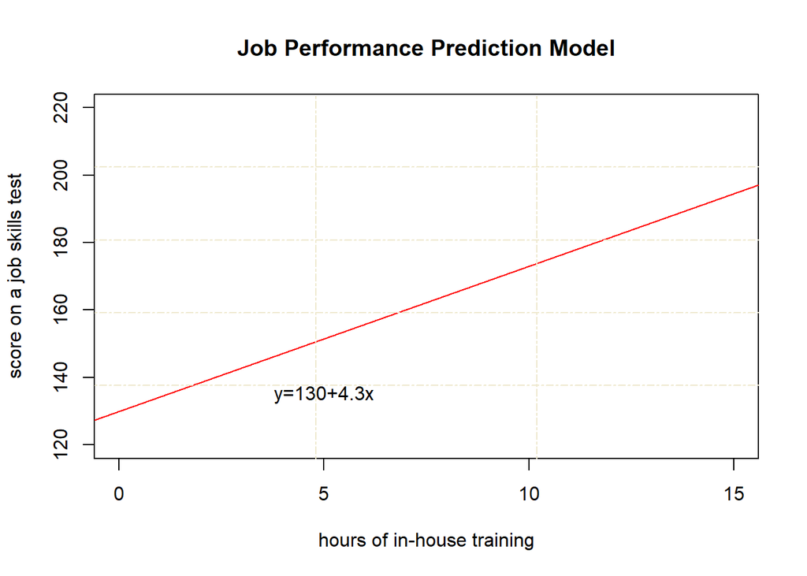

```r
# y=130+4.3x
plot(1,type = "n", xlab = "hours of in-house training",ylab = "score on a job skills test",  xlim = c(0,15), ylim = c(120,220))

title("Job Performance Prediction Model")

text(5,135,"y=130+4.3x")
abline(a=130, b=4.3, col="red")
grid (3,5, lty = 6, col = "cornsilk2")
```

### 4. Multiple Plot in Single Canvas

- `mfrow()`
- `mfcol()`

```r
# 100 random numbers
x <- rnorm(100)
y <- rnorm(100)
z <- rpois(100,2)
```

#### 4.1. Multiple Plot: 2-rows & 1-column

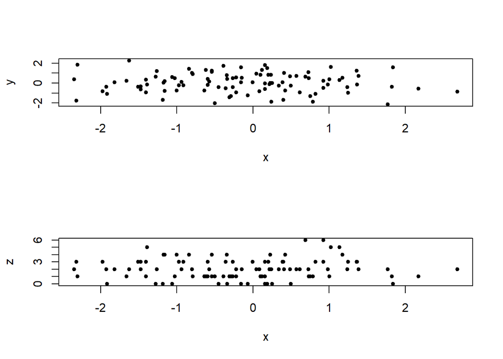

```r
par(mfrow = c(2,1))
plot(x,y,pch=20)
plot(x,z,pch=20)
```

#### 4.2. Multiple Plot: 1-rows & 2-columns

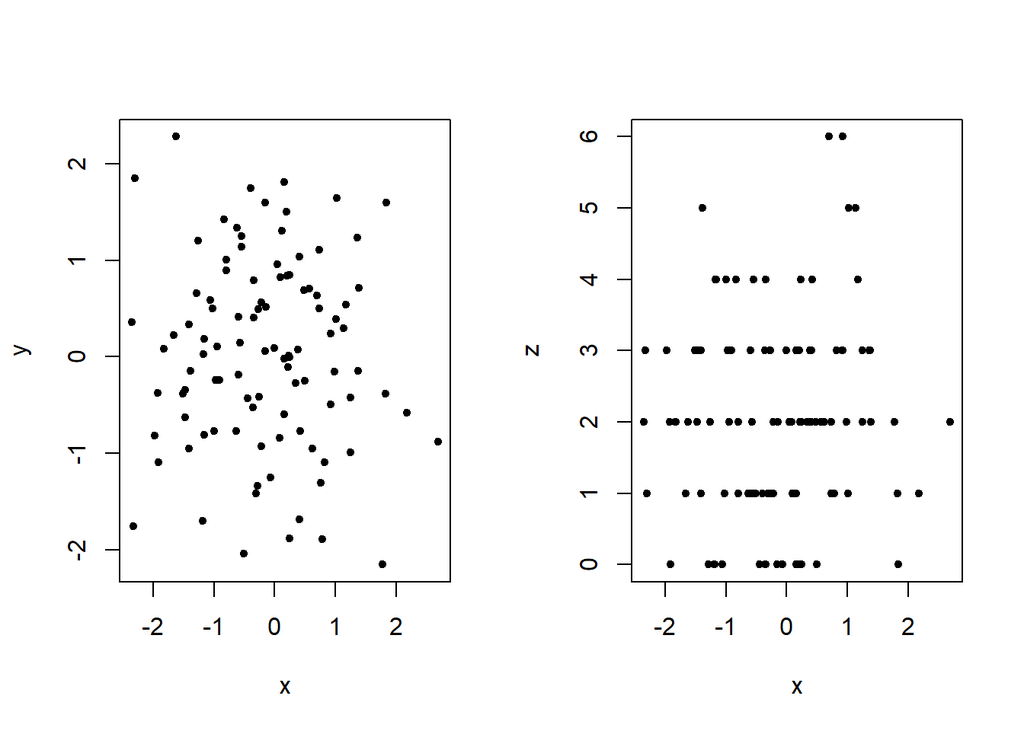

```r
par(mfrow = c(1,2))
plot(x,y,pch=20)
plot(x,z,pch=20)
```

#### 4.3. Multiple Plot (row-wise): 2-rows & 2-columns

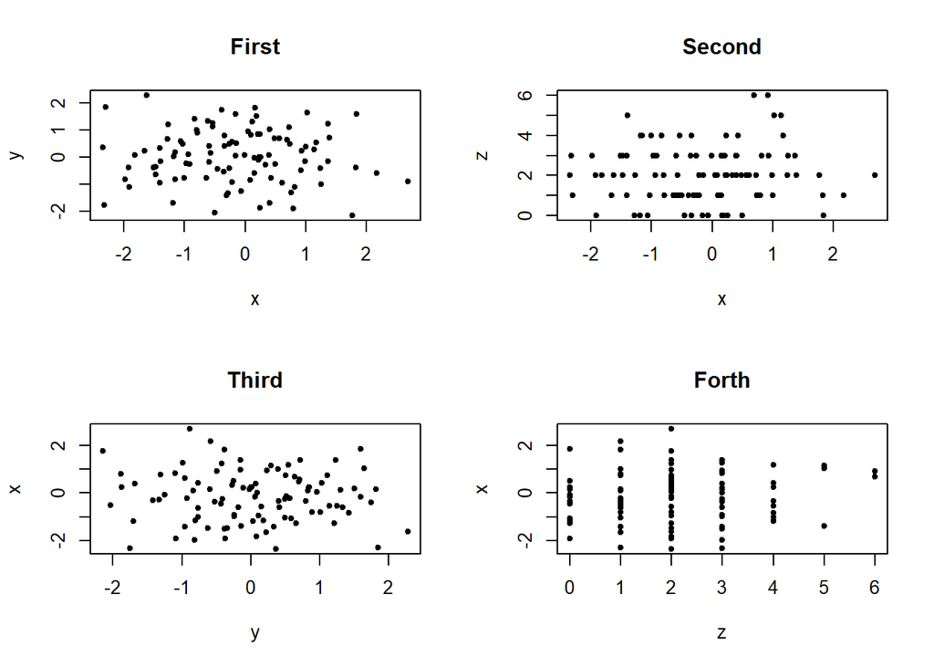

```r
par(mfrow = c(2,2))
plot(x,y,pch=20, main = "First")
plot(x,z,pch=20, main = "Second")
plot(y,x,pch=20, main = "Third")
plot(z,x,pch=20, main = "Forth")
```

#### 4.4. Multiple Plot (column-wise): 2-rows & 2-columns

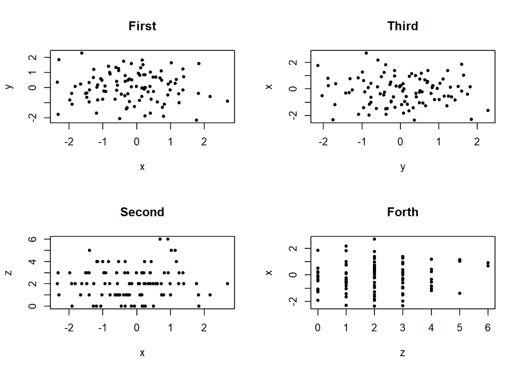

```r
par(mfcol = c(2,2))
plot(x,y,pch=20, main = "First")
plot(x,z,pch=20, main = "Second")
plot(y,x,pch=20, main = "Third")
plot(z,x,pch=20, main = "Forth")
```

### 5. Points Variable

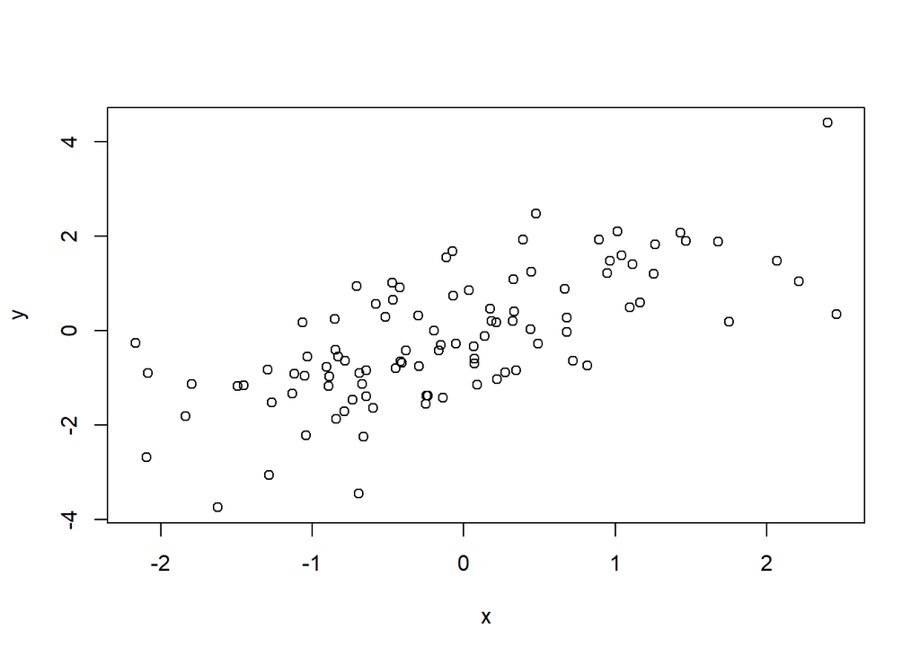

```r
# Plot of random numbers
x <- rnorm(100)
y <- x + rnorm(100)

plot(x,y)
```

```r
# Factor Object containing Male and Female data

g <- gl(2,50, labels = c("Male","Female"))

print(g)
```

```
##   [1] Male   Male   Male   Male   Male   Male   Male   Male   Male   Male
##  [11] Male   Male   Male   Male   Male   Male   Male   Male   Male   Male
##  [21] Male   Male   Male   Male   Male   Male   Male   Male   Male   Male
##  [31] Male   Male   Male   Male   Male   Male   Male   Male   Male   Male
##  [41] Male   Male   Male   Male   Male   Male   Male   Male   Male   Male
##  [51] Female Female Female Female Female Female Female Female Female Female
##  [61] Female Female Female Female Female Female Female Female Female Female
##  [71] Female Female Female Female Female Female Female Female Female Female
##  [81] Female Female Female Female Female Female Female Female Female Female
##  [91] Female Female Female Female Female Female Female Female Female Female
## Levels: Male Female
```

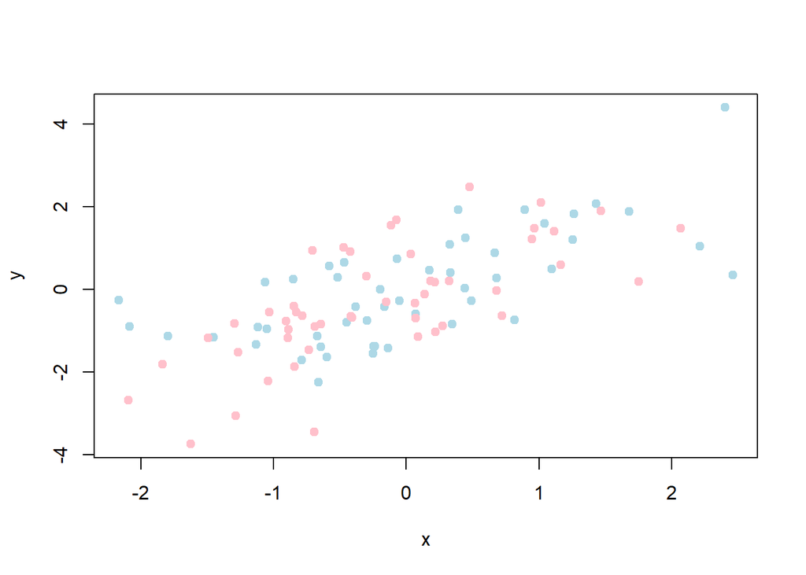

```r
# Blank Plot
plot(x,y, type = "n")

# Add Male points to graph
points(x[g=="Male"],y[g=="Male"], col = "light blue",pch=19)

# Add Female points to graph
points(x[g=="Female"],y[g=="Female"], col = "pink", pch=19)
```